# Risk Factor Analysis

## Outcome Variable

**Outcome Variable:** swasted

## Predictor Variables

**Intervention Variable:** predfeed6

**Adjustment Set:**

- arm
- sex
- month
- brthmon
- W_mage
- meducyrs
- feducyrs
- hhwealth_quart
- hfoodsec
- W_mhtcm
- vagbrth
- W_gagebrth
- W_birthwt
- W_birthlen
- W_nrooms
- W_nchldlt5
- W_parity
- impfloor
- impsan
- safeh20
- delta_W_mage
- delta_meducyrs
- delta_feducyrs
- delta_hhwealth_quart
- delta_hfoodsec
- delta_W_mhtcm
- delta_vagbrth
- delta_W_gagebrth
- delta_W_birthwt
- delta_W_birthlen
- delta_W_nrooms
- delta_W_nchldlt5
- delta_W_parity
- delta_impfloor
- delta_impsan
- delta_safeh20

## Stratifying Variables

The analysis was stratified on these variable(s):

- agecat
- studyid
- country

## Data Summary

| agecat | studyid | country | predfeed6 | swasted | n_cell | n |
| --- | --- | --- | --- | --- | --- | --- |
| Birth | ki0047075b-MAL-ED | BANGLADESH | 0 | 0 | 98 | 219 |
| Birth | ki0047075b-MAL-ED | BANGLADESH | 0 | 1 | 7 | 219 |
| Birth | ki0047075b-MAL-ED | BANGLADESH | 1 | 0 | 113 | 219 |
| Birth | ki0047075b-MAL-ED | BANGLADESH | 1 | 1 | 1 | 219 |
| Birth | ki0047075b-MAL-ED | BRAZIL | 0 | 0 | 142 | 168 |
| Birth | ki0047075b-MAL-ED | BRAZIL | 0 | 1 | 0 | 168 |
| Birth | ki0047075b-MAL-ED | BRAZIL | 1 | 0 | 26 | 168 |
| Birth | ki0047075b-MAL-ED | BRAZIL | 1 | 1 | 0 | 168 |
| Birth | ki0047075b-MAL-ED | INDIA | 0 | 0 | 166 | 187 |
| Birth | ki0047075b-MAL-ED | INDIA | 0 | 1 | 6 | 187 |
| Birth | ki0047075b-MAL-ED | INDIA | 1 | 0 | 15 | 187 |
| Birth | ki0047075b-MAL-ED | INDIA | 1 | 1 | 0 | 187 |
| Birth | ki0047075b-MAL-ED | NEPAL | 0 | 0 | 139 | 165 |
| Birth | ki0047075b-MAL-ED | NEPAL | 0 | 1 | 4 | 165 |
| Birth | ki0047075b-MAL-ED | NEPAL | 1 | 0 | 22 | 165 |
| Birth | ki0047075b-MAL-ED | NEPAL | 1 | 1 | 0 | 165 |
| Birth | ki0047075b-MAL-ED | PERU | 0 | 0 | 145 | 249 |
| Birth | ki0047075b-MAL-ED | PERU | 0 | 1 | 0 | 249 |
| Birth | ki0047075b-MAL-ED | PERU | 1 | 0 | 104 | 249 |
| Birth | ki0047075b-MAL-ED | PERU | 1 | 1 | 0 | 249 |
| Birth | ki0047075b-MAL-ED | SOUTH AFRICA | 0 | 0 | 205 | 209 |
| Birth | ki0047075b-MAL-ED | SOUTH AFRICA | 0 | 1 | 1 | 209 |
| Birth | ki0047075b-MAL-ED | SOUTH AFRICA | 1 | 0 | 3 | 209 |
| Birth | ki0047075b-MAL-ED | SOUTH AFRICA | 1 | 1 | 0 | 209 |
| Birth | ki0047075b-MAL-ED | TANZANIA, UNITED REPUBLIC OF | 0 | 0 | 113 | 115 |
| Birth | ki0047075b-MAL-ED | TANZANIA, UNITED REPUBLIC OF | 0 | 1 | 1 | 115 |
| Birth | ki0047075b-MAL-ED | TANZANIA, UNITED REPUBLIC OF | 1 | 0 | 1 | 115 |
| Birth | ki0047075b-MAL-ED | TANZANIA, UNITED REPUBLIC OF | 1 | 1 | 0 | 115 |
| Birth | ki1000109-EE | PAKISTAN | 0 | 0 | 2 | 2 |
| Birth | ki1000109-EE | PAKISTAN | 0 | 1 | 0 | 2 |

[output cut: 106 more lines]

The following strata were considered:

- agecat: 24 months, studyid: ki0047075b-MAL-ED, country: BANGLADESH
- agecat: 24 months, studyid: ki0047075b-MAL-ED, country: BRAZIL
- agecat: 24 months, studyid: ki0047075b-MAL-ED, country: INDIA
- agecat: 24 months, studyid: ki0047075b-MAL-ED, country: NEPAL
- agecat: 24 months, studyid: ki0047075b-MAL-ED, country: PERU
- agecat: 24 months, studyid: ki0047075b-MAL-ED, country: SOUTH AFRICA
- agecat: 24 months, studyid: ki0047075b-MAL-ED, country: TANZANIA, UNITED REPUBLIC OF
- agecat: 24 months, studyid: ki1113344-GMS-Nepal, country: NEPAL
- agecat: 24 months, studyid: ki1148112-LCNI-5, country: MALAWI
- agecat: 24 months, studyid: kiGH5241-JiVitA-3, country: BANGLADESH
- agecat: 24 months, studyid: kiGH5241-JiVitA-4, country: BANGLADESH
- agecat: 6 months, studyid: ki0047075b-MAL-ED, country: BANGLADESH
- agecat: 6 months, studyid: ki0047075b-MAL-ED, country: BRAZIL
- agecat: 6 months, studyid: ki0047075b-MAL-ED, country: INDIA
- agecat: 6 months, studyid: ki0047075b-MAL-ED, country: NEPAL
- agecat: 6 months, studyid: ki0047075b-MAL-ED, country: PERU
- agecat: 6 months, studyid: ki0047075b-MAL-ED, country: SOUTH AFRICA
- agecat: 6 months, studyid: ki0047075b-MAL-ED, country: TANZANIA, UNITED REPUBLIC OF
- agecat: 6 months, studyid: ki1000109-EE, country: PAKISTAN
- agecat: 6 months, studyid: ki1000304b-SAS-FoodSuppl, country: INDIA
- agecat: 6 months, studyid: ki1113344-GMS-Nepal, country: NEPAL
- agecat: 6 months, studyid: ki1148112-LCNI-5, country: MALAWI
- agecat: 6 months, studyid: kiGH5241-JiVitA-3, country: BANGLADESH
- agecat: 6 months, studyid: kiGH5241-JiVitA-4, country: BANGLADESH
- agecat: Birth, studyid: ki0047075b-MAL-ED, country: BANGLADESH
- agecat: Birth, studyid: ki0047075b-MAL-ED, country: BRAZIL
- agecat: Birth, studyid: ki0047075b-MAL-ED, country: INDIA
- agecat: Birth, studyid: ki0047075b-MAL-ED, country: NEPAL
- agecat: Birth, studyid: ki0047075b-MAL-ED, country: PERU
- agecat: Birth, studyid: ki0047075b-MAL-ED, country: SOUTH AFRICA
- agecat: Birth, studyid: ki0047075b-MAL-ED, country: TANZANIA, UNITED REPUBLIC OF
- agecat: Birth, studyid: ki1000109-EE, country: PAKISTAN
- agecat: Birth, studyid: kiGH5241-JiVitA-3, country: BANGLADESH
- agecat: Birth, studyid: kiGH5241-JiVitA-4, country: BANGLADESH

### Dropped Strata

Some strata were dropped due to rare outcomes:

- agecat: Birth, studyid: ki0047075b-MAL-ED, country: BANGLADESH
- agecat: Birth, studyid: ki0047075b-MAL-ED, country: BRAZIL
- agecat: Birth, studyid: ki0047075b-MAL-ED, country: INDIA
- agecat: Birth, studyid: ki0047075b-MAL-ED, country: NEPAL
- agecat: Birth, studyid: ki0047075b-MAL-ED, country: PERU
- agecat: Birth, studyid: ki0047075b-MAL-ED, country: SOUTH AFRICA
- agecat: Birth, studyid: ki0047075b-MAL-ED, country: TANZANIA, UNITED REPUBLIC OF
- agecat: Birth, studyid: ki1000109-EE, country: PAKISTAN
- agecat: Birth, studyid: kiGH5241-JiVitA-4, country: BANGLADESH
- agecat: 6 months, studyid: ki0047075b-MAL-ED, country: BANGLADESH
- agecat: 6 months, studyid: ki0047075b-MAL-ED, country: BRAZIL
- agecat: 6 months, studyid: ki0047075b-MAL-ED, country: INDIA
- agecat: 6 months, studyid: ki0047075b-MAL-ED, country: NEPAL
- agecat: 6 months, studyid: ki0047075b-MAL-ED, country: PERU
- agecat: 6 months, studyid: ki0047075b-MAL-ED, country: SOUTH AFRICA
- agecat: 6 months, studyid: ki0047075b-MAL-ED, country: TANZANIA, UNITED REPUBLIC OF
- agecat: 6 months, studyid: ki1000109-EE, country: PAKISTAN
- agecat: 6 months, studyid: ki1000304b-SAS-FoodSuppl, country: INDIA
- agecat: 6 months, studyid: ki1113344-GMS-Nepal, country: NEPAL
- agecat: 6 months, studyid: ki1148112-LCNI-5, country: MALAWI
- agecat: 24 months, studyid: ki0047075b-MAL-ED, country: BANGLADESH
- agecat: 24 months, studyid: ki0047075b-MAL-ED, country: BRAZIL
- agecat: 24 months, studyid: ki0047075b-MAL-ED, country: INDIA
- agecat: 24 months, studyid: ki0047075b-MAL-ED, country: NEPAL
- agecat: 24 months, studyid: ki0047075b-MAL-ED, country: PERU
- agecat: 24 months, studyid: ki0047075b-MAL-ED, country: SOUTH AFRICA
- agecat: 24 months, studyid: ki0047075b-MAL-ED, country: TANZANIA, UNITED REPUBLIC OF
- agecat: 24 months, studyid: ki1148112-LCNI-5, country: MALAWI

## Methods Detail

We’re interested in the causal parameters $E[Y_a]$ for all values of $a \in \mathcal{A}$. These parameters represent the mean outcome if, possibly contrary to fact, we intervened to set all units to have $A=a$. Under the randomization and positivity assumptions, these are identified by the statistical parameters $\psi_a=E_W[E_{Y|A,W}(Y|A=a,W)]$. In addition, we’re interested in the mean of $Y$, $E[Y]$ under no intervention (the observed mean). We will estimate these parameters by using SuperLearner to fit the relevant likelihood factors – $E_{Y|A,W}(Y|A=a,W)$ and $p(A=a|W)$, and then updating our likelihood fit using a joint TMLE.

For unadjusted analyses ($W=\{\}$), initial likelihoods were estimated using Lrnr_glm to estimate the simple $E(Y|A)$ and Lrnr_mean to estimate $p(A)$. For adjusted analyses, a small library containing Lrnr_glmnet, Lrnr_xgboost, and Lrnr_mean was used.

Having estimated these parameters, we will then use the delta method to estimate relative risks and attributable risks relative to a prespecified baseline level of $A$.

# Results Detail

## Results Plots

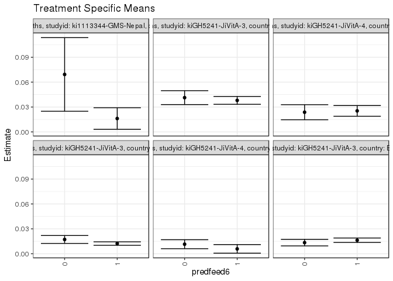

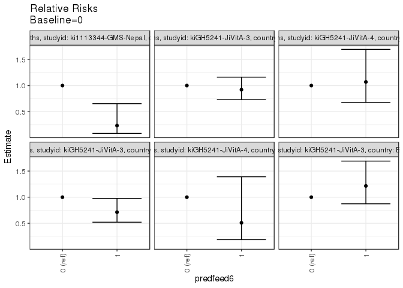

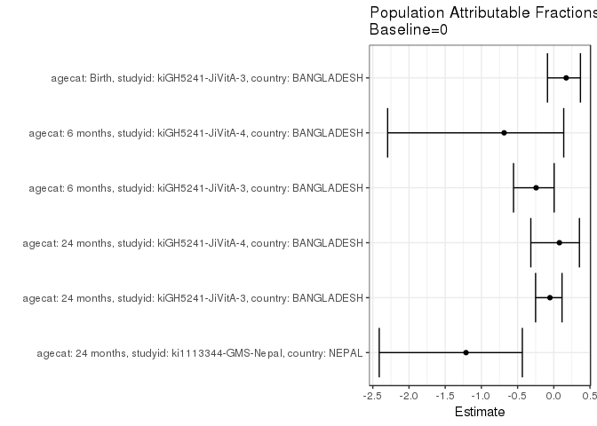

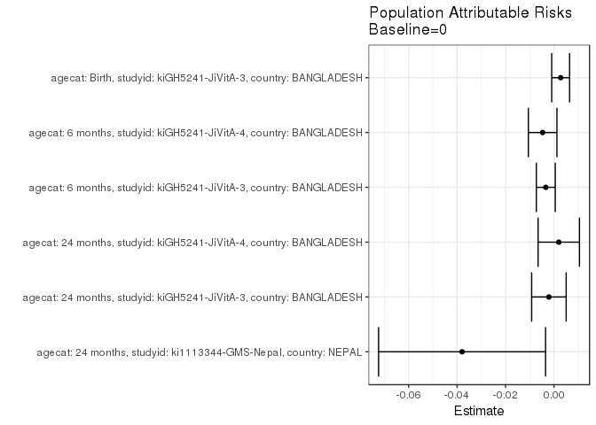

## Results Table

### Parameter: TSM

| agecat | studyid | country | intervention_level | baseline_level | estimate | ci_lower | ci_upper |
| --- | --- | --- | --- | --- | --- | --- | --- |
| Birth | kiGH5241-JiVitA-3 | BANGLADESH | 0 | NA | 0.0133823 | 0.0094397 | 0.0173250 |
| Birth | kiGH5241-JiVitA-3 | BANGLADESH | 1 | NA | 0.0162602 | 0.0135759 | 0.0189444 |
| 6 months | kiGH5241-JiVitA-3 | BANGLADESH | 0 | NA | 0.0171842 | 0.0124148 | 0.0219537 |
| 6 months | kiGH5241-JiVitA-3 | BANGLADESH | 1 | NA | 0.0122515 | 0.0101598 | 0.0143433 |
| 6 months | kiGH5241-JiVitA-4 | BANGLADESH | 0 | NA | 0.0114791 | 0.0060542 | 0.0169041 |
| 6 months | kiGH5241-JiVitA-4 | BANGLADESH | 1 | NA | 0.0058489 | 0.0006744 | 0.0110233 |
| 24 months | ki1113344-GMS-Nepal | NEPAL | 0 | NA | 0.0692757 | 0.0249164 | 0.1136351 |
| 24 months | ki1113344-GMS-Nepal | NEPAL | 1 | NA | 0.0161459 | 0.0031540 | 0.0291379 |
| 24 months | kiGH5241-JiVitA-3 | BANGLADESH | 0 | NA | 0.0413168 | 0.0329379 | 0.0496956 |
| 24 months | kiGH5241-JiVitA-3 | BANGLADESH | 1 | NA | 0.0380090 | 0.0332732 | 0.0427448 |
| 24 months | kiGH5241-JiVitA-4 | BANGLADESH | 0 | NA | 0.0237290 | 0.0146426 | 0.0328155 |
| 24 months | kiGH5241-JiVitA-4 | BANGLADESH | 1 | NA | 0.0253482 | 0.0188855 | 0.0318109 |

### Parameter: E(Y)

| agecat | studyid | country | intervention_level | baseline_level | estimate | ci_lower | ci_upper |
| --- | --- | --- | --- | --- | --- | --- | --- |
| Birth | kiGH5241-JiVitA-3 | BANGLADESH | NA | NA | 0.0161479 | 0.0137874 | 0.0185083 |
| 6 months | kiGH5241-JiVitA-3 | BANGLADESH | NA | NA | 0.0138097 | 0.0117159 | 0.0159035 |
| 6 months | kiGH5241-JiVitA-4 | BANGLADESH | NA | NA | 0.0068075 | 0.0025982 | 0.0110168 |
| 24 months | ki1113344-GMS-Nepal | NEPAL | NA | NA | 0.0313152 | 0.0157016 | 0.0469288 |
| 24 months | kiGH5241-JiVitA-3 | BANGLADESH | NA | NA | 0.0392341 | 0.0348275 | 0.0436407 |
| 24 months | kiGH5241-JiVitA-4 | BANGLADESH | NA | NA | 0.0257273 | 0.0200920 | 0.0313626 |

### Parameter: RR

| agecat | studyid | country | intervention_level | baseline_level | estimate | ci_lower | ci_upper |
| --- | --- | --- | --- | --- | --- | --- | --- |
| Birth | kiGH5241-JiVitA-3 | BANGLADESH | 0 | 0 | 1.0000000 | 1.0000000 | 1.0000000 |
| Birth | kiGH5241-JiVitA-3 | BANGLADESH | 1 | 0 | 1.2150452 | 0.8731927 | 1.6907322 |
| 6 months | kiGH5241-JiVitA-3 | BANGLADESH | 0 | 0 | 1.0000000 | 1.0000000 | 1.0000000 |
| 6 months | kiGH5241-JiVitA-3 | BANGLADESH | 1 | 0 | 0.7129519 | 0.5211255 | 0.9753897 |
| 6 months | kiGH5241-JiVitA-4 | BANGLADESH | 0 | 0 | 1.0000000 | 1.0000000 | 1.0000000 |
| 6 months | kiGH5241-JiVitA-4 | BANGLADESH | 1 | 0 | 0.5095203 | 0.1866572 | 1.3908435 |
| 24 months | ki1113344-GMS-Nepal | NEPAL | 0 | 0 | 1.0000000 | 1.0000000 | 1.0000000 |
| 24 months | ki1113344-GMS-Nepal | NEPAL | 1 | 0 | 0.2330679 | 0.0831910 | 0.6529628 |
| 24 months | kiGH5241-JiVitA-3 | BANGLADESH | 0 | 0 | 1.0000000 | 1.0000000 | 1.0000000 |
| 24 months | kiGH5241-JiVitA-3 | BANGLADESH | 1 | 0 | 0.9199415 | 0.7293426 | 1.1603496 |
| 24 months | kiGH5241-JiVitA-4 | BANGLADESH | 0 | 0 | 1.0000000 | 1.0000000 | 1.0000000 |
| 24 months | kiGH5241-JiVitA-4 | BANGLADESH | 1 | 0 | 1.0682360 | 0.6744747 | 1.6918769 |

### Parameter: PAR

| agecat | studyid | country | intervention_level | baseline_level | estimate | ci_lower | ci_upper |
| --- | --- | --- | --- | --- | --- | --- | --- |
| Birth | kiGH5241-JiVitA-3 | BANGLADESH | 0 | NA | 0.0027655 | -0.0009301 | 0.0064611 |
| 6 months | kiGH5241-JiVitA-3 | BANGLADESH | 0 | NA | -0.0033746 | -0.0072811 | 0.0005320 |
| 6 months | kiGH5241-JiVitA-4 | BANGLADESH | 0 | NA | -0.0046716 | -0.0105790 | 0.0012357 |
| 24 months | ki1113344-GMS-Nepal | NEPAL | 0 | NA | -0.0379605 | -0.0724545 | -0.0034665 |
| 24 months | kiGH5241-JiVitA-3 | BANGLADESH | 0 | NA | -0.0020827 | -0.0092085 | 0.0050432 |
| 24 months | kiGH5241-JiVitA-4 | BANGLADESH | 0 | NA | 0.0019983 | -0.0065493 | 0.0105460 |

### Parameter: PAF

| agecat | studyid | country | intervention_level | baseline_level | estimate | ci_lower | ci_upper |
| --- | --- | --- | --- | --- | --- | --- | --- |
| Birth | kiGH5241-JiVitA-3 | BANGLADESH | 0 | NA | 0.1712617 | -0.0871249 | 0.3682353 |
| 6 months | kiGH5241-JiVitA-3 | BANGLADESH | 0 | NA | -0.2443634 | -0.5561723 | 0.0049687 |
| 6 months | kiGH5241-JiVitA-4 | BANGLADESH | 0 | NA | -0.6862458 | -2.2953090 | 0.1371295 |
| 24 months | ki1113344-GMS-Nepal | NEPAL | 0 | NA | -1.2122043 | -2.4116050 | -0.4344709 |
| 24 months | kiGH5241-JiVitA-3 | BANGLADESH | 0 | NA | -0.0530829 | -0.2514237 | 0.1138224 |
| 24 months | kiGH5241-JiVitA-4 | BANGLADESH | 0 | NA | 0.0776727 | -0.3172609 | 0.3541996 |